# Progress Memo 1

Final Project  
Data Science 2 with R (STAT 301-2)

Author

Sarah Norman

Published

January 30, 2025

**Github Repo Link**

[Sarah’s Repo Link (sarahdnor)](https://github.com/stat301-2-2025-winter/final-project-2-sarahdnor.git)

**Access to Data Source**

Link:

[Malawi Longitudinal Study of Families and Health)](https://www.icpsr.umich.edu/web/DSDR/studies/20840)

Apa citation:

Behrman, J. R., Chimbiri, A. M., Chimwaza, A., Kohler, H.-P., & Watkins, S. C. (2008, May 21). Malawi Longitudinal Study of families and Health (MLSFH). Malawi Longitudinal Study of Families and Health (MLSFH). https://www.icpsr.umich.edu/web/DSDR/studies/20840

## Prediction problem

For this assignment, I aim to predict the future monthly earnings of women in Malawi three years ahead using a variety of predictor variables, including education, demographic characteristics, and occupation.

The Malawi Longitudinal Study of Families and Health (MLSFH) was conducted in two waves on the same set of individuals, with Wave 1 in 1998 collecting baseline data and Wave 2 in 2001 following up with the same individuals. In this prediction problem, the target variable, monthly earnings of Malawian women, will be taken from Wave 2 (2001), while predictor variables will be sourced from Wave 1 (1998). The goal is to predict future earnings three years ahead based on earlier characteristics.

This is a supervised predictive regression problem. The goal of producing these predictive models on earnings is to observe and explore which subsets of variables yield the most accurate predictions and provide insights into the most important factors in predicting earnings. These findings could help inform future research on how Malawian women might optimize their future earnings by highlighting how different models with different subsets of variables predict earnings.

This information may fuel further studies on how women may go about optimizing their future earnings by witnessing patterns in variables and predictions through this report.

## Why this data

This dataset was introduced to me by a guest lecturer in my International Studies class, Foundations in Global Sustainability. Our guest lecturer, Crystal Burke, emphasized the importance of the dataset’s high response rate, considering the number of respondents, the context in which the study took place, and the effort to track down respondents for each wave, all of which contribute to the quantitative strength of the dataset. However, Crystal also highlighted the potential biases in the survey questions and interviews. For example, face-to-face interviews conducted by foreign interviewers may have made respondents hesitant to provide accurate responses. Additionally, bias in question structure, such as using methodologies like asking proportions with beans and two bowls, may have offended respondents and made them feel belittled or undermined. These criticisms will be acknowledged in the report and will also provide valuable reflection post results

As an international studies major I always strive to explore a new country of interest when possible in assignments. Given Malawi’s status as a developing country, I was particularly interested in applying predictive modeling to forecast monthly earnings—an incredibly influential factor for women who face systemic oppression and for those living below the poverty line. I am eager to explore which combinations of variables produce the most accurate predictions, which variables may overpredict or underpredict earnings, and how researchers might use modeling techniques to address missing data in potential future waves of the study. This study might provide insight into which variables could be interesting to explore in future causal research.

## Data source

As mentioned above, the data I will be using for this report is from the Malawi Longitudinal Study of Families and Health (MLSFH) (ICPSR 20840) which was requested and downloaded from Data Sharing for Demographic Research (DSDR), a Population Health Data Archive[^1]. The study provides demographic, socioeconomic, and health data from rural Malawi, one of the world’s poorest countries. The study has contributed to more than 150 publications and informed health policy in Malawi and Sub-Saharan Africa, focusing on social interactions in demographic behavior, health conditions, HIV risk, and family dynamics.

<sup>1</sup> Behrman, J. R., Chimbiri, A. M., Chimwaza, A., Kohler, H.-P., & Watkins, S. C. (2008, May 21). Malawi Longitudinal Study of families and Health (MLSFH).`https://www.icpsr.umich.edu/web/DSDR/studies/20840`

# Basic Summary

From the data summary, we can see that the dataset contains a total of 1,953 rows and 682 columns. Among the columns, 68 are character variables, 24 are logical variables, and 590 are numeric variables. The full summary of the data can be seen in the collapsed callout box below however a basic summary is represented in Table 1 and Table 2.

Table 1: Variable Types

| variable_type | n |
| --- | --- |
| character | 68 |
| logical | 24 |
| numeric | 590 |

Table 2: Number of Rows and Columns Respectivley

| n |
| --- |
| 1953 |
| 682 |

# Missingness

The data exhibits significant missingness across variables which can be explored in the table below, with 422 variables having over 20% of responses missing. These variables can be explored in Table 3. This is understandable, as not all respondents in the study were administered the same set of questions. Some questions were specific to certain waves, some were reserved for particular subgroups, and others were follow-up questions. For instance, questions about the year the 7th marriage ended, the year the 8th marriage ended, and similar queries had 100% missingness. On the other hand, questions considered more core, such as the year the respondent was born, tend to have higher response rates as they were asked to a greater majority of respondents.

Table 3: Percentage of Missingness for Variables with Greater than or Equal to 20% Missingness

|  | variable | n_miss | pct_miss |
| --- | --- | --- | --- |
| 1 | m2wothl | 1953 | 100 |
| 2 | m2wm5a8s | 1953 | 100 |
| 3 | m2wm5a8e | 1953 | 100 |
| 4 | m2wm5a9s | 1953 | 100 |
| 5 | m2wm5a9e | 1953 | 100 |
| 6 | m2wm5a10s | 1953 | 100 |
| 7 | m2wm5a10e | 1953 | 100 |
| 8 | m2wm8fot | 1953 | 100 |
| 9 | m2wm9fot | 1953 | 100 |
| 10 | m2wm10fo | 1953 | 100 |

[output cut: 584 more lines]

As a result, variables must be carefully filtered and selected for model building due to the large number of potential variables and significant missingness.

# Data tidying

As seen in Table 3, all variable names are carefully coded with different number/letter combinations indicating unique questions. However, this can be confusing for analysis and interpretation. As a result, future predictor variables and the target variable may have their naming conventions changed so that variables are less reliant on the codebook and more easily interpreted by the general reader—for example, changing `M2WB1` to `year_born`. However, it would be difficult to do this for all variables. As a result, a future dataset could be created with just the most significant/used variables to make changing names more efficient and the dataset more palatable.

Additionally, some coded values, discussed further in the target variable analysis, are used to represent non-numerical values (e.g., 88 or 77) as another means of inputting N/A, indicating that the respondent “doesn’t know.” Therefore, the codebook will need to be referenced for the used variables to ensure there isn’t a greater range of missing values. It will then have to be assessed, such as whether to impute or remove values.

**Full summary of data**

Data summary

| Name | malawi_data |
| --- | --- |
| Number of rows | 1953 |
| Number of columns | 682 |
| _______________________ |  |
| Column type frequency: |  |
| character | 68 |
| logical | 24 |
| numeric | 590 |
| ________________________ |  |
| Group variables | None |

**Variable type: character**

| skim_variable | n_missing | complete_rate | min | max | empty | n_unique | whitespace |
| --- | --- | --- | --- | --- | --- | --- | --- |
| m2wtnam | 0 | 1.00 | 6 | 8 | 0 | 4 | 0 |
| m2wdint | 44 | 0.98 | 11 | 11 | 0 | 55 | 0 |
| m2wvi1ot | 1347 | 0.31 | 4 | 20 | 0 | 278 | 0 |
| m2wv2ot | 1906 | 0.02 | 5 | 20 | 0 | 40 | 0 |
| m2wv3ot | 1942 | 0.01 | 8 | 20 | 0 | 8 | 0 |
| m2wb6pr | 1615 | 0.17 | 3 | 19 | 0 | 10 | 0 |
| m2wb6re | 1904 | 0.03 | 4 | 25 | 0 | 16 | 0 |
| m2wb6ot | 1451 | 0.26 | 3 | 25 | 0 | 28 | 0 |
| m2wb7ot | 1917 | 0.02 | 5 | 13 | 0 | 16 | 0 |
| m2wb8jot | 1837 | 0.06 | 4 | 15 | 0 | 38 | 0 |
| m2wb9aot | 1853 | 0.05 | 5 | 18 | 0 | 75 | 0 |
| m2we2ot | 1948 | 0.00 | 7 | 12 | 0 | 5 | 0 |
| m2we4ot | 1912 | 0.02 | 5 | 14 | 0 | 31 | 0 |
| m2we5ot | 1952 | 0.00 | 12 | 12 | 0 | 1 | 0 |
| monthly_earningsot | 1950 | 0.00 | 9 | 12 | 0 | 3 | 0 |
| m2wm8cot | 1948 | 0.00 | 11 | 13 | 0 | 4 | 0 |
| m2wm8pot | 1949 | 0.00 | 7 | 12 | 0 | 3 | 0 |
| m2wm9cot | 1948 | 0.00 | 3 | 15 | 0 | 5 | 0 |
| m2wm9pot | 1952 | 0.00 | 15 | 15 | 0 | 1 | 0 |
| m2wm10co | 1944 | 0.00 | 1 | 15 | 0 | 9 | 0 |
| m2wm10po | 1948 | 0.00 | 3 | 14 | 0 | 5 | 0 |
| m2wm11co | 1880 | 0.04 | 4 | 15 | 0 | 39 | 0 |
| m2wm11po | 1919 | 0.02 | 4 | 15 | 0 | 18 | 0 |
| m2wm11fo | 1949 | 0.00 | 7 | 8 | 0 | 3 | 0 |
| m2wm14co | 1932 | 0.01 | 4 | 14 | 0 | 10 | 0 |
| m2wm14po | 1937 | 0.01 | 5 | 9 | 0 | 12 | 0 |
| m2wm14fo | 1949 | 0.00 | 6 | 9 | 0 | 3 | 0 |
| m2wf121o | 1941 | 0.01 | 5 | 19 | 0 | 10 | 0 |
| m2wf122o | 1937 | 0.01 | 4 | 19 | 0 | 14 | 0 |
| m2wf123o | 1939 | 0.01 | 4 | 19 | 0 | 12 | 0 |
| m2wf124o | 1948 | 0.00 | 8 | 19 | 0 | 5 | 0 |
| m2w15a1o | 1506 | 0.23 | 3 | 20 | 0 | 68 | 0 |
| m2w15a2o | 1535 | 0.21 | 3 | 20 | 0 | 74 | 0 |
| m2w15a3o | 1542 | 0.21 | 3 | 20 | 0 | 71 | 0 |
| m2w15a4o | 1614 | 0.17 | 3 | 20 | 0 | 64 | 0 |
| m2wf27ko | 1950 | 0.00 | 7 | 21 | 0 | 3 | 0 |
| m2wp7ot | 1947 | 0.00 | 6 | 18 | 0 | 5 | 0 |
| m2wp8ot | 1943 | 0.01 | 5 | 9 | 0 | 9 | 0 |
| m2wp20ot | 1949 | 0.00 | 7 | 18 | 0 | 4 | 0 |
| m2wa2ot | 1945 | 0.00 | 9 | 23 | 0 | 8 | 0 |
| m2wa6mot | 1856 | 0.05 | 1 | 19 | 0 | 31 | 0 |
| m2wa275o | 1924 | 0.01 | 10 | 17 | 0 | 10 | 0 |
| m2wa276o | 1920 | 0.02 | 7 | 26 | 0 | 12 | 0 |
| m2wa277o | 1935 | 0.01 | 10 | 17 | 0 | 9 | 0 |
| m2wa278o | 1935 | 0.01 | 10 | 26 | 0 | 10 | 0 |
| m2wa31o5 | 1941 | 0.01 | 8 | 24 | 0 | 11 | 0 |
| m2wa31o6 | 1939 | 0.01 | 6 | 24 | 0 | 13 | 0 |
| m2wa31o7 | 1943 | 0.01 | 8 | 24 | 0 | 9 | 0 |
| m2wa31o8 | 1946 | 0.00 | 8 | 24 | 0 | 7 | 0 |
| m2wi6ao1 | 1479 | 0.24 | 1 | 76 | 0 | 339 | 0 |
| m2wi6ao2 | 1938 | 0.01 | 7 | 68 | 0 | 15 | 0 |
| m2wi6ao4 | 1937 | 0.01 | 7 | 52 | 0 | 16 | 0 |
| m2wi6bo1 | 1785 | 0.09 | 4 | 75 | 0 | 106 | 0 |
| m2wi6bo3 | 1952 | 0.00 | 2 | 2 | 0 | 1 | 0 |
| m2wi6bo4 | 1947 | 0.00 | 7 | 26 | 0 | 6 | 0 |
| m2wi6co1 | 1725 | 0.12 | 2 | 76 | 0 | 205 | 0 |
| m2wi6co2 | 1944 | 0.00 | 10 | 51 | 0 | 9 | 0 |
| m2wi6co4 | 1946 | 0.00 | 25 | 37 | 0 | 7 | 0 |
| m2wi6do1 | 1785 | 0.09 | 2 | 76 | 0 | 158 | 0 |
| m2wi6do2 | 1947 | 0.00 | 8 | 59 | 0 | 6 | 0 |
| m2wi6do4 | 1950 | 0.00 | 31 | 42 | 0 | 3 | 0 |
| m2wi8 | 439 | 0.78 | 2 | 80 | 0 | 652 | 0 |
| m2wi802 | 435 | 0.78 | 2 | 80 | 0 | 1100 | 0 |
| m2wi803 | 1380 | 0.29 | 1 | 80 | 0 | 548 | 0 |
| m2wi10 | 1903 | 0.03 | 1 | 79 | 0 | 50 | 0 |
| m2wi9 | 1652 | 0.15 | 1 | 76 | 0 | 296 | 0 |
| m2wi902 | 707 | 0.64 | 2 | 80 | 0 | 510 | 0 |
| m2wi6eo1 | 1568 | 0.20 | 2 | 76 | 0 | 321 | 0 |

**Variable type: logical**

| skim_variable | n_missing | complete_rate | mean | count |
| --- | --- | --- | --- | --- |
| m2wothl | 1953 | 0 | NaN | : |
| m2wm5a8s | 1953 | 0 | NaN | : |
| m2wm5a8e | 1953 | 0 | NaN | : |
| m2wm5a9s | 1953 | 0 | NaN | : |
| m2wm5a9e | 1953 | 0 | NaN | : |
| m2wm5a10s | 1953 | 0 | NaN | : |
| m2wm5a10e | 1953 | 0 | NaN | : |
| m2wm8fot | 1953 | 0 | NaN | : |
| m2wm9fot | 1953 | 0 | NaN | : |
| m2wm10fo | 1953 | 0 | NaN | : |
| m2wm12bc | 1953 | 0 | NaN | : |
| m2wm23fd | 1953 | 0 | NaN | : |
| m2wf30jo | 1953 | 0 | NaN | : |
| m2wf33ko | 1953 | 0 | NaN | : |
| m2wp5ot | 1953 | 0 | NaN | : |
| m2wp6ot | 1953 | 0 | NaN | : |
| m2wp18ot | 1953 | 0 | NaN | : |
| m2wp19ot | 1953 | 0 | NaN | : |
| m2wp21ot | 1953 | 0 | NaN | : |
| m2wi6ao3 | 1953 | 0 | NaN | : |
| m2wi6bo2 | 1953 | 0 | NaN | : |
| m2wi6co3 | 1953 | 0 | NaN | : |
| m2wi6do3 | 1953 | 0 | NaN | : |
| wi6foth1 | 1953 | 0 | NaN | : |

**Variable type: numeric**

| skim_variable | n_missing | complete_rate | mean | sd | p0 | p25 | p50 | p75 | p100 |
| --- | --- | --- | --- | --- | --- | --- | --- | --- | --- |
| CASEID | 0 | 1.00 | 977.00 | 563.93 | 1 | 489.00 | 977.0 | 1465.00 | 1953 |
| sample01 | 0 | 1.00 | 1.10 | 0.30 | 1 | 1.00 | 1.0 | 1.00 | 2 |
| hholdnum | 29 | 0.99 | 925.58 | 532.22 | 1 | 466.00 | 911.5 | 1380.25 | 1872 |
| m2wqqnum | 0 | 1.00 | 74296.79 | 76519.18 | 2000 | 21008.00 | 76012.0 | 104007.00 | 946521 |
| m2poly | 192 | 0.90 | 0.27 | 0.44 | 0 | 0.00 | 0.0 | 1.00 | 1 |
| m2numw | 196 | 0.90 | 1.33 | 0.62 | 1 | 1.00 | 1.0 | 2.00 | 5 |
| m2wnewh | 361 | 0.82 | 0.02 | 0.13 | 0 | 0.00 | 0.0 | 0.00 | 1 |
| m2wvilnu | 1 | 1.00 | 76.05 | 155.37 | 1 | 13.00 | 57.0 | 111.00 | 2007 |
| m2whs01 | 303 | 0.84 | 2.17 | 0.86 | 1 | 1.00 | 2.0 | 3.00 | 4 |
| m2wrf01 | 309 | 0.84 | 1.90 | 0.30 | 1 | 2.00 | 2.0 | 2.00 | 2 |
| m2winla | 326 | 0.83 | 2.18 | 0.88 | 1 | 1.00 | 2.0 | 3.00 | 3 |
| m2wvi1 | 1 | 1.00 | 1.63 | 0.93 | 1 | 1.00 | 1.0 | 3.00 | 3 |
| m2wv2 | 1728 | 0.12 | 1.41 | 0.80 | 1 | 1.00 | 1.0 | 1.00 | 3 |
| m2wv3 | 1889 | 0.03 | 1.38 | 0.77 | 1 | 1.00 | 1.0 | 1.00 | 3 |
| m2wsamv | 829 | 0.58 | 0.90 | 0.31 | 0 | 1.00 | 1.0 | 1.00 | 1 |
| m2wb1 | 378 | 0.81 | 1720.47 | 635.29 | 88 | 1956.00 | 1966.0 | 1974.00 | 1999 |
| m2wb1b | 1748 | 0.10 | 38.98 | 9.78 | 19 | 31.00 | 39.0 | 45.00 | 70 |
| m2wb5a | 388 | 0.80 | 0.67 | 0.47 | 0 | 0.00 | 1.0 | 1.00 | 1 |
| m2wb5b | 917 | 0.53 | 1.11 | 0.37 | 1 | 1.00 | 1.0 | 1.00 | 4 |
| m2wb5c | 907 | 0.54 | 5.04 | 4.32 | 1 | 3.00 | 5.0 | 7.00 | 88 |
| m2wb5d | 385 | 0.80 | 2.48 | 10.54 | 0 | 0.00 | 0.0 | 3.00 | 88 |
| m2wb5e | 386 | 0.80 | 4.24 | 12.91 | 0 | 3.00 | 3.0 | 3.00 | 88 |
| m2wb6 | 385 | 0.80 | 3.98 | 2.32 | 1 | 2.00 | 4.0 | 7.00 | 7 |
| m2wb6a | 385 | 0.80 | 1.54 | 0.81 | 1 | 1.00 | 1.0 | 2.00 | 5 |
| m2wb6b | 387 | 0.80 | 3.50 | 1.22 | 1 | 3.00 | 4.0 | 5.00 | 5 |
| m2wb6c | 386 | 0.80 | 4.25 | 1.26 | 1 | 4.00 | 5.0 | 5.00 | 5 |
| m2wb6d | 386 | 0.80 | 0.11 | 0.32 | 0 | 0.00 | 0.0 | 0.00 | 1 |
| m2wb6e | 1775 | 0.09 | 1802.25 | 576.65 | 88 | 1989.00 | 1998.0 | 2000.00 | 2001 |
| m2wb7 | 385 | 0.80 | 3.01 | 2.84 | 1 | 2.00 | 2.0 | 4.00 | 88 |
| m2wb8a | 397 | 0.80 | 0.35 | 0.48 | 0 | 0.00 | 0.0 | 1.00 | 1 |

[output cut: 560 more lines]

## Target variable analysis

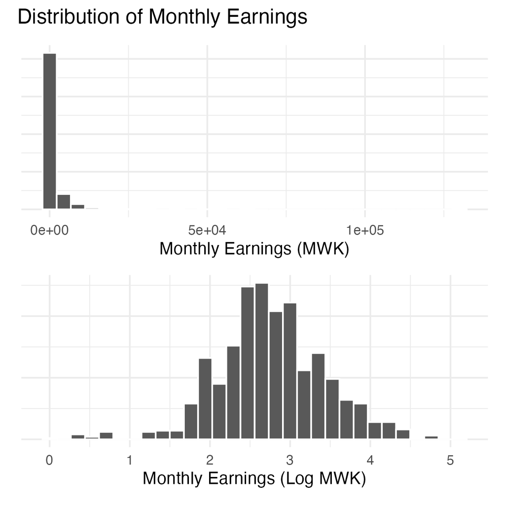

Figure 1: Distribution of Monthly Earnings of Malawian Women (Before and After Log Transformation of Earnings)

## Next steps

Immediate next steps involve grouping variables together to define models, as well as selecting the models that will be used for this report. There may be value in extracting the relevant variables that will be used, as mentioned before, to avoid having hundreds of variables with specifically coded names, which can make interpretation difficult for the general reader. The next few weeks will look as follows:

Week 5 will focus on splitting the data, defining the desired models, and selecting the groups of variables to be used for prediction.

Weeks 6 & 7 will involve defining and fitting the models. If possible, this week will also include calculating RMSE (Root Mean Squared Error) to evaluate model performance.

Week 8 will be dedicated to qualitative analysis of the insights gained from the models and data discovered in the previous weeks.

Tasks and timeline will be adjsuted accordingly demending on workload and complexity.